# Rihal_challenge_ml

## Import the necessary libraries

```python
import numpy as np
import pandas as pd
import json
from glob import glob
import cv2
import matplotlib.pylab as plt
import nltk
import re
from nltk.corpus import stopwords
from nltk.tokenize import word_tokenize
from nltk.stem import WordNetLemmatizer
import seaborn as sns
import matplotlib.pyplot as plt
from collections import Counter
import nltk
from nltk.tokenize import word_tokenize
from imblearn.over_sampling import RandomOverSampler
from imblearn.under_sampling import RandomUnderSampler
from sklearn.feature_extraction.text import CountVectorizer
from sklearn.naive_bayes import MultinomialNB
from sklearn.metrics import accuracy_score, confusion_matrix, classification_report

# Download NLTK resources
nltk.download('omw-1.4')

# Set the plotting style
plt.style.use('ggplot')
```

## Load the datasets and understand them

```python
#Load the JSON file
nytimes_train = '/Users/rawanr/Desktop/R/N24News/news/nytimes_train.json'
with open(nytimes_train, 'r') as f:
    nytimes_train = json.load(f)

# Print the first 2 row
for i, row in enumerate(nytimes_train[:2]):
    print(f"Row {i+1}:")
    print(row)
    print()
```

```
Row 1:
{'section': 'Theater', 'headline': "Before 'Moonlight' and 'The Walking Dead,' a Friendship Born in the Classroom", 'article_url': 'https://www.nytimes.com/2017/02/21/theater/danai-gurira-andre-holland-walking-dead.html', 'article': 'Danai Gurira and Andre Holland in a theater at New York University…

Row 2:
{'section': 'Television', 'headline': "What's on TV Wednesday: 'Crip Camp' and 'Dark Phoenix'", 'article_url': 'https://www.nytimes.com/2020/03/25/arts/television/whats-on-tv-wednesday-crip-camp-and-dark-phoenix.html', 'article': 'CRIP CAMP: A DISABILITY REVOLUTION (2020) Stream on Netflix. This doc…
```

```python
nytimes_test = '/Users/rawanr/Desktop/R/N24News/news/nytimes_test.json'
with open(nytimes_test, 'r') as f:
    nytimes_test = json.load(f)

for i, row in enumerate(nytimes_test[:2]):
    print(f"Row {i+1}:")
    print(row)
    print()
```

```
Row 1:
{'section': 'Travel', 'headline': 'Afropunk, Huichica and More: 8 Music Festivals to Hit This Year', 'article_url': 'https://www.nytimes.com/2019/03/15/travel/afropunk-huichica-and-more-8-music-festivals-to-hit-this-year.html', 'article': 'An act at the FORM festival, held at Arcosanti in Arizona.\n…

Row 2:
{'section': 'Style', 'headline': 'The Repurposing of a Vogue Editor', 'article_url': 'https://www.nytimes.com/2019/04/09/style/tonne-goodman-vogue-memoir.html', 'article': 'Tonne Goodman has a mantra for when things start to get a little messy: "This is happening for a reason." She is known for sayi…
```

## Preprocessing the text data

```python
#nytimes_train
nytimes_train_df = pd.DataFrame(nytimes_train)

def clean_text(text):
    # Remove non-alphanumeric characters and convert to lowercase
    text = re.sub(r'[^a-zA-Z\s]', '', text.lower())
    return text

def remove_stopwords(text):
    stop_words = set(stopwords.words('english'))
    word_tokens = word_tokenize(text)
    filtered_text = [word for word in word_tokens if word not in stop_words]
    return filtered_text

def lemmatize_text(text):
    lemmatizer = WordNetLemmatizer()
    lemmatized_text = [lemmatizer.lemmatize(word) for word in text]
    return lemmatized_text

# Apply preprocessing to relevant textual features
textual_features = ['headline', 'article', 'abstract', 'caption']
for feature in textual_features:
    nytimes_train_df[f'cleaned_{feature}_train'] = nytimes_train_df[feature].apply(clean_text)
    nytimes_train_df[f'cleaned_{feature}_train'] = nytimes_train_df[f'cleaned_{feature}_train'].apply(remove_stopwords)
    nytimes_train_df[f'cleaned_{feature}_train'] = nytimes_train_df[f'cleaned_{feature}_train'].apply(lemmatize_text)

# Join tokens back to text
for feature in textual_features:
    nytimes_train_df[f'cleaned_{feature}_train'] = nytimes_train_df[f'cleaned_{feature}_train'].apply(lambda x: ' '.join(x))

# Handling empty documents and replacing missing values for all textual features
for feature in textual_features:
    nytimes_train_df[f'cleaned_{feature}_train'] = nytimes_train_df[f'cleaned_{feature}_train'].replace('', pd.NA)

# Replace missing values for all textual features
nytimes_train_df.fillna('', inplace=True)

# Additional filtering step to remove empty documents after complete preprocessing for all textual features
for feature in textual_features:
    nytimes_train_df = nytimes_train_df[nytimes_train_df[f'cleaned_{feature}_train'] != '']


# Display the preprocessed data
print(nytimes_train_df.head())
```

```
        section                                           headline  \
0       Theater  Before 'Moonlight' and 'The Walking Dead,' a F...
1    Television  What's on TV Wednesday: 'Crip Camp' and 'Dark ...
2        Sports  Rays Stick to Their Plan and Reach a 2nd World...
3  Art & Design    For Robert Rauschenberg, No Artist Is an Island
4       Theater  Jimmy Buffett's 'Margaritaville' Musical Sets ...

                                         article_url  \
0  https://www.nytimes.com/2017/02/21/theater/dan...
1  https://www.nytimes.com/2020/03/25/arts/televi...
2  https://www.nytimes.com/2020/10/17/sports/base...
3  https://www.nytimes.com/2017/05/11/arts/design...
4  https://www.nytimes.com/2017/06/05/theater/jim...

                                             article  \
```

[output cut: 68 more lines]

```python
#nytimes_test
nytimes_test_df = pd.DataFrame(nytimes_test)

def clean_text(text):
    text = re.sub(r'[^a-zA-Z\s]', '', text.lower())
    return text

def remove_stopwords(text):
    stop_words = set(stopwords.words('english'))
    word_tokens = word_tokenize(text)
    filtered_text = [word for word in word_tokens if word not in stop_words]
    return filtered_text

def lemmatize_text(text):
    lemmatizer = WordNetLemmatizer()
    lemmatized_text = [lemmatizer.lemmatize(word) for word in text]
    return lemmatized_text

textual_features = ['headline', 'article', 'abstract', 'caption']
for feature in textual_features:
    nytimes_test_df[f'cleaned_{feature}_test'] = nytimes_test_df[feature].apply(clean_text)
    nytimes_test_df[f'cleaned_{feature}_test'] = nytimes_test_df[f'cleaned_{feature}_test'].apply(remove_stopwords)
    nytimes_test_df[f'cleaned_{feature}_test'] = nytimes_test_df[f'cleaned_{feature}_test'].apply(lemmatize_text)

for feature in textual_features:
    nytimes_test_df[f'cleaned_{feature}_test'] = nytimes_test_df[f'cleaned_{feature}_test'].apply(lambda x: ' '.join(x))

for feature in textual_features:
    nytimes_test_df[f'cleaned_{feature}_test'] = nytimes_test_df[f'cleaned_{feature}_test'].replace('', pd.NA)

nytimes_test_df.fillna('', inplace=True)

for feature in textual_features:
    nytimes_test_df = nytimes_test_df[nytimes_test_df[f'cleaned_{feature}_test'] != '']

print(nytimes_test_df.head())
```

```
       section                                           headline  \
0       Travel  Afropunk, Huichica and More: 8 Music Festivals...
1        Style                  The Repurposing of a Vogue Editor
2  Real Estate                           Sites for Aviation Buffs
3   Television  What's on TV Monday: 'Amy Schumer Learns to Co...
4      Economy  Argentina Raises Key Rate to 40%, Bringing Eco...

                                         article_url  \
0  https://www.nytimes.com/2019/03/15/travel/afro...
1  https://www.nytimes.com/2019/04/09/style/tonne...
2  https://www.nytimes.com/2016/12/13/realestate/...
3  https://www.nytimes.com/2020/08/17/arts/televi...
4  https://www.nytimes.com/2018/05/04/business/ec...

                                             article  \
```

[output cut: 68 more lines]

In the preprocessing phase for both the training and testing datasets, I cleaned and standardized textual features. This involved removing non-alphanumeric characters, converting text to lowercase, removing stopwords, and lemmatizing words. These steps were applied to each textual feature ('headline', 'article', 'abstract', 'caption') and missing values were handled by replacing empty documents with NaN values.

Finally, I filtered out rows with empty documents post-preprocessing to ensure data integrity and uniform representation for further analysis and modeling.

## Data Analysis and Exploration

## Training dataset

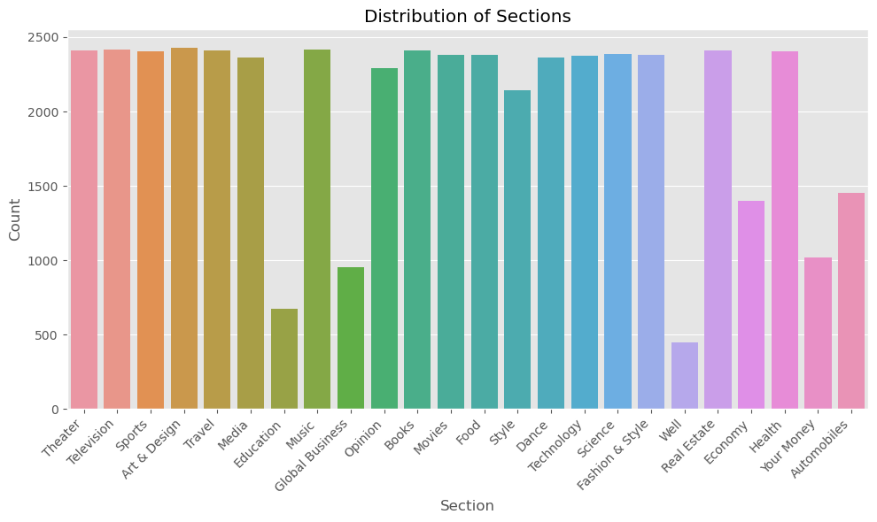

```python
# Create a count plot to visualize the distribution of each 'section' type:

plt.figure(figsize=(10, 6))
sns.countplot(data=nytimes_train_df, x='section')
plt.title('Distribution of Sections')
plt.xlabel('Section')
plt.ylabel('Count')
plt.xticks(rotation=45, ha='right')  # Rotate x-axis labels for better readability
plt.tight_layout()
plt.show()
```

```python
# Calculate the percentages of each section type for training dataset:

section_counts = nytimes_train_df['section'].value_counts()
section_percentages = (section_counts / section_counts.sum()) * 100
# Print the percentages
print("Section percentages:")
print(section_percentages)
```

```
Section percentages:
Art & Design       4.987378
Television         4.964801
Music              4.956591
Travel             4.950434
Books              4.948382
Real Estate        4.946329
Theater            4.942224
Sports             4.938120
Health             4.929910
Science            4.897071
Movies             4.890914
Food               4.890914
Fashion & Style    4.882704
Technology         4.874495
Dance              4.851918
Media              4.847813
Opinion            4.704144
Style              4.394229
Automobiles        2.986269
Economy            2.869281
Your Money         2.093467
Global Business    1.960060
Education          1.377173
Well               0.915379
Name: section, dtype: float64
```

```python
# Get the top words for each section for training dataset:

# Tokenize function
def tokenize(text):
    return word_tokenize(text)

# Group the DataFrame by 'section' and tokenize the text
grouped = nytimes_train_df.groupby('section')['cleaned_headline_train'].apply(' '.join).apply(tokenize)

# Define the number of top words
top_words_count = 10

top_words_by_section = {}
for section, words in grouped.items():
    # Count occurrences of each word
    word_counts = Counter(words)
    # Get the top words
    top_words = word_counts.most_common(top_words_count)
    top_words_by_section[section] = top_words

# Print the top words for each section
for section, top_words in top_words_by_section.items():
    print(f"Top words in section '{section}':")
    for word, count in top_words:
        print(f"{word}: {count}")
    print()
```

```
Top words in section 'Art & Design':
art: 732
museum: 342
new: 334
gallery: 206
artist: 184
york: 176
see: 154
show: 133
nyc: 117
week: 115

Top words in section 'Automobiles':
car: 167
wheelies: 150
edition: 149
recall: 69
new: 67
driven: 57
motorsports: 47
auto: 47
video: 46
monday: 43

Top words in section 'Books':
book: 370
novel: 171
new: 162
dy: 132
life: 108
story: 89
woman: 80
america: 69
author: 68
writer: 66

Top words in section 'Dance':
dance: 654
review: 630
ballet: 396
```

[output cut: 232 more lines]

```
marathon: 15
need: 14
kid: 14

Top words in section 'Your Money':
tax: 52
new: 47
money: 42
financial: 42
college: 40
retirement: 35
family: 30
way: 30
investment: 28
market: 28
```

```python
#check data imblance for training dataset:

# Count the occurrences of each class label
class_counts = nytimes_train_df['section'].value_counts()

# Display the class counts
print("Class distribution for section class in Training dataset:")
print(class_counts)

# Calculate the class imbalance ratio
imbalance_ratio = class_counts.max() / class_counts.min()
print("Imbalance ratio for section class in Training dataset:", imbalance_ratio)
```

```
Class distribution for section class in Training dataset:
Art & Design       2430
Television         2419
Music              2415
Travel             2412
Books              2411
Real Estate        2410
Theater            2408
Sports             2406
Health             2402
Science            2386
Movies             2383
Food               2383
Fashion & Style    2379
Technology         2375
Dance              2364
Media              2362
Opinion            2292
Style              2141
Automobiles        1455
Economy            1398
Your Money         1020
Global Business     955
Education           671
Well                446
Name: section, dtype: int64
Imbalance ratio for section class in Training dataset: 5.448430493273543
```

```python
# Apply oversampling or undersampling to balance the classes :

# Identify class distribution
class_distribution_train = nytimes_train_df['section'].value_counts()

# Set threshold for class imbalance
threshold = 1000

# Identify minority and majority classes
minority_classes_train = class_distribution_train[class_distribution_train < threshold].index
majority_classes_train = class_distribution_train[class_distribution_train >= threshold].index

oversampler = RandomOverSampler()
undersampler = RandomUnderSampler()

X_train = nytimes_train_df.drop(columns=['section'])
y_train = nytimes_train_df['section']

if len(minority_classes_train) > 0:
    X_train_resampled, y_train_resampled = oversampler.fit_resample(X_train, y_train)
elif len(majority_classes_train) > 0:
    X_train_resampled, y_train_resampled = undersampler.fit_resample(X_train, y_train)
else:
    X_train_resampled, y_train_resampled = X_train, y_train

# Ensure balanced class distribution after resampling
print("Class distribution after resampling for section class in Training dataset:")
print(y_train_resampled.value_counts())
```

```
Class distribution after resampling for section class in Training dataset:
Theater            2430
Television         2430
Your Money         2430
Health             2430
Economy            2430
Real Estate        2430
Well               2430
Fashion & Style    2430
Science            2430
Technology         2430
Dance              2430
Style              2430
Food               2430
Movies             2430
Books              2430
Opinion            2430
Global Business    2430
Music              2430
Education          2430
Media              2430
Travel             2430
Art & Design       2430
Sports             2430
Automobiles        2430
Name: section, dtype: int64
```

## Testing dataset

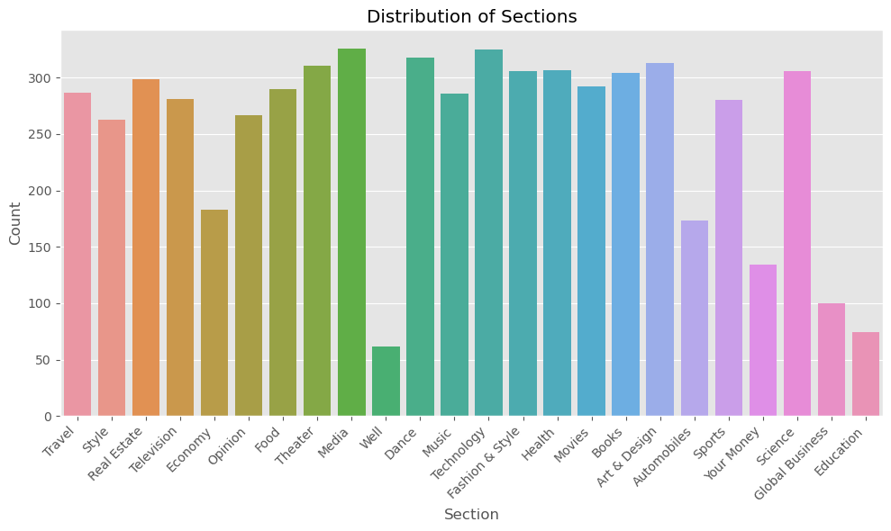

```python
# Create a count plot to visualize the distribution of each 'section' type:

plt.figure(figsize=(10, 6))
sns.countplot(data=nytimes_test_df, x='section')
plt.title('Distribution of Sections')
plt.xlabel('Section')
plt.ylabel('Count')
plt.xticks(rotation=45, ha='right')
plt.tight_layout()
plt.show()
```

```python
# Get the counts of each section type for testing dataset:

section_counts = nytimes_test_df['section'].value_counts()
section_percentages = (section_counts / section_counts.sum()) * 100
print("Section percentages:")
print(section_percentages)
```

```
Section percentages:
Media              5.355676
Technology         5.339248
Dance              5.224248
Art & Design       5.142106
Theater            5.109249
Health             5.043535
Fashion & Style    5.027107
Science            5.027107
Books              4.994250
Real Estate        4.912108
Movies             4.797109
Food               4.764252
Travel             4.714966
Music              4.698538
Television         4.616396
Sports             4.599967
Opinion            4.386397
Style              4.320683
Economy            3.006407
Automobiles        2.842123
Your Money         2.201413
Global Business    1.642845
Education          1.215706
Well               1.018564
Name: section, dtype: float64
```

```python
# Get the top words for each section for testing dataset:

def tokenize(text):
    return word_tokenize(text)

grouped = nytimes_test_df.groupby('section')['cleaned_headline_test'].apply(' '.join).apply(tokenize)

top_words_count = 10

top_words_by_section = {}
for section, words in grouped.items():
    word_counts = Counter(words)
    top_words = word_counts.most_common(top_words_count)
    top_words_by_section[section] = top_words

for section, top_words in top_words_by_section.items():
    print(f"Top words in section '{section}':")
    for word, count in top_words:
        print(f"{word}: {count}")
    print()
```

```
Top words in section 'Art & Design':
art: 92
museum: 42
new: 42
gallery: 30
york: 26
artist: 25
see: 23
nyc: 19
week: 19
show: 15

Top words in section 'Automobiles':
wheelies: 16
edition: 16
car: 15
new: 10
auto: 10
show: 10
bmw: 8
monday: 8
motorsports: 8
coupe: 6

Top words in section 'Books':
book: 40
new: 19
dy: 19
novel: 18
life: 16
world: 13
literary: 13
story: 11
novelist: 11
war: 10

Top words in section 'Dance':
dance: 96
review: 89
ballet: 51
```

[output cut: 232 more lines]

```
childrens: 3
parent: 3
lesson: 2

Top words in section 'Your Money':
tax: 9
new: 7
money: 7
retirement: 7
college: 6
care: 5
plan: 5
look: 5
market: 5
help: 5
```

```python
#check data imblance for testing dataset:

class_counts2 = nytimes_test_df['section'].value_counts()
print("Class distribution for section class in testing dataset:")
print(class_counts2)
imbalance_ratio2 = class_counts2.max() / class_counts2.min()
print("Imbalance ratio for section class in testing dataset:", imbalance_ratio2)
```

```
Class distribution for section class in testing dataset:
Media              326
Technology         325
Dance              318
Art & Design       313
Theater            311
Health             307
Fashion & Style    306
Science            306
Books              304
Real Estate        299
Movies             292
Food               290
Travel             287
Music              286
Television         281
Sports             280
Opinion            267
Style              263
Economy            183
Automobiles        173
Your Money         134
Global Business    100
Education           74
Well                62
Name: section, dtype: int64
Imbalance ratio for section class in testing dataset: 5.258064516129032
```

```python
# Apply oversampling or undersampling to balance the classes in testing dataset :

from imblearn.over_sampling import RandomOverSampler
from imblearn.under_sampling import RandomUnderSampler

# Identify class distribution
class_distribution_test = nytimes_test_df['section'].value_counts()
threshold = 1000

# Identify minority and majority classes
minority_classes_test = class_distribution_test[class_distribution_test < threshold].index
majority_classes_test = class_distribution_test[class_distribution_test >= threshold].index

oversampler = RandomOverSampler()
undersampler = RandomUnderSampler()

X_train = nytimes_test_df.drop(columns=['section'])
y_train = nytimes_test_df['section']

if len(minority_classes_test) > 0:
    X_train_resampled, y_train_resampled = oversampler.fit_resample(X_train, y_train)
elif len(majority_classes_train) > 0:
    X_train_resampled, y_train_resampled = undersampler.fit_resample(X_train, y_train)
else:
    X_train_resampled, y_train_resampled = X_train, y_train

print("Class distribution after resampling for section class in testing dataset:")
print(y_train_resampled.value_counts())
```

```
Class distribution after resampling for section class in testing dataset:
Travel             326
Style              326
Global Business    326
Science            326
Your Money         326
Sports             326
Automobiles        326
Art & Design       326
Books              326
Movies             326
Health             326
Fashion & Style    326
Technology         326
Music              326
Dance              326
Well               326
Media              326
Theater            326
Food               326
Opinion            326
Economy            326
Television         326
Real Estate        326
Education          326
Name: section, dtype: int64
```

In the data analysis and exploration step for both the training and testing datasets, I initially visualized the distribution of each section type using count plots. This provided insights into the proportion of articles belonging to different categories. Additionally, I calculated the percentages of each section type to understand their relative frequencies within the datasets.

Furthermore, I extracted the top words for each section in both datasets to identify common themes or topics. Comparing the top words between the training and testing datasets revealed similarities and differences in the most frequent terms associated with each section.

Finally, I checked for data imbalance within each dataset by examining the class distribution of section types. I applied oversampling or undersampling techniques to balance the classes, ensuring that each section type had a similar representation in the datasets.

## Naive Bayes

```python
# Container for sentences
news = np.array([headline for headline in nytimes_train_df['cleaned_headline_train']])

# Container for labels
labels = np.array([label for label in nytimes_train_df['section']])

# Tokenization using CountVectorizer
vectorizer = CountVectorizer()
X_train = vectorizer.fit_transform(news)

model_nb = MultinomialNB()

# Training
model_nb.fit(X_train, labels)
```

```
MultinomialNB()
```

## Evaluation with Testing Dataset

```
Accuracy on testing data: 0.5406604238541153
Classification Report:
                 precision    recall  f1-score   support

   Art & Design       0.57      0.61      0.59       313
    Automobiles       0.60      0.51      0.55       173
          Books       0.48      0.44      0.46       304
          Dance       0.73      0.71      0.72       318
        Economy       0.59      0.54      0.56       183
      Education       0.31      0.34      0.32        74
Fashion & Style       0.40      0.44      0.42       306
           Food       0.60      0.57      0.59       290
Global Business       0.39      0.46      0.42       100
         Health       0.57      0.58      0.57       307
          Media       0.59      0.58      0.58       326
         Movies       0.56      0.67      0.61       292
          Music       0.65      0.62      0.63       286
        Opinion       0.40      0.41      0.41       267
    Real Estate       0.51      0.59      0.55       299
        Science       0.58      0.50      0.53       306
         Sports       0.72      0.66      0.69       280
          Style       0.19      0.17      0.18       263
     Technology       0.60      0.62      0.61       325
     Television       0.66      0.65      0.66       281
        Theater       0.60      0.56      0.58       311
         Travel       0.51      0.55      0.53       287
           Well       0.18      0.21      0.19        62
     Your Money       0.36      0.33      0.35       134

       accuracy                           0.54      6087
      macro avg       0.51      0.51      0.51      6087
   weighted avg       0.54      0.54      0.54      6087
```

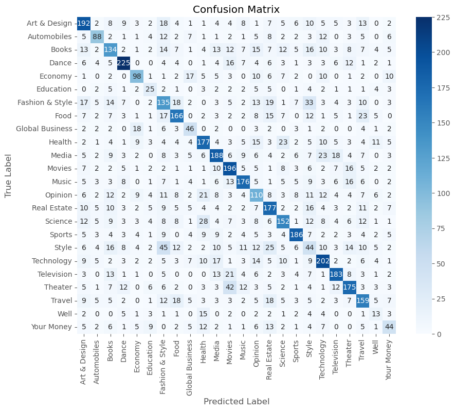

```python
from sklearn.metrics import accuracy_score, classification_report, confusion_matrix
import seaborn as sns
import matplotlib.pyplot as plt

# Instantiate LabelEncoder
label_encoder = LabelEncoder()

# Fit and transform labels
encoded_test_labels = label_encoder.fit_transform(test_labels)

# Evaluate the model
accuracy = accuracy_score(encoded_test_labels, predictions)
print("Accuracy on testing data:", accuracy)
report = classification_report(encoded_test_labels, predictions, target_names=label_encoder.classes_)
print("Classification Report:")
print(report)

# Plot confusion matrix
conf_matrix = confusion_matrix(encoded_test_labels, predictions)
plt.figure(figsize=(10, 8))
sns.heatmap(conf_matrix, annot=True, fmt="d", cmap="Blues", xticklabels=label_encoder.classes_, yticklabels=label_encoder.classes_)
plt.title("Confusion Matrix")
plt.xlabel("Predicted Label")
plt.ylabel("True Label")
plt.show()
```

## BiLSTM

```python
# Container for sentences
news = np.array([headline for headline in nytimes_train_df['cleaned_headline_train']])

# Container for labels
labels = np.array([label for label in nytimes_train_df['section']])

# Tokenization
tokenizer = Tokenizer()
tokenizer.fit_on_texts(news)
word_index = tokenizer.word_index
vocab_size = len(word_index) + 1

sequences = tokenizer.texts_to_sequences(news)

# Padding
maxlen = 100  # You can adjust the maximum length of sequences as needed
padded_sequences = pad_sequences(sequences, maxlen=maxlen, padding='post')

# Encoding labels
label_encoder = LabelEncoder()
encoded_labels = label_encoder.fit_transform(labels)

# Model Architecture
embedding_dim = 100
model = Sequential()
model.add(Embedding(input_dim=vocab_size, output_dim=embedding_dim))  # Removed input_length argument
model.add(Bidirectional(LSTM(64)))
model.add(Dense(len(label_encoder.classes_), activation='softmax'))

# Compile the Model
model.compile(optimizer='adam', loss='sparse_categorical_crossentropy', metrics=['accuracy'])

# Training
model.fit(padded_sequences, encoded_labels, epochs=10, batch_size=32, validation_split=0.2)
```

```
1219/1219 ━━━━━━━━━━━━━━━━━━━━ 65s 53ms/step - accuracy: 0.2718 - loss: 2.5102 - val_accuracy: 0.5944 - val_loss: 1.4563
1219/1219 ━━━━━━━━━━━━━━━━━━━━ 66s 54ms/step - accuracy: 0.7469 - loss: 0.9229 - val_accuracy: 0.6263 - val_loss: 1.3572
1219/1219 ━━━━━━━━━━━━━━━━━━━━ 66s 54ms/step - accuracy: 0.8753 - loss: 0.4515 - val_accuracy: 0.6187 - val_loss: 1.5115
1219/1219 ━━━━━━━━━━━━━━━━━━━━ 66s 54ms/step - accuracy: 0.9353 - loss: 0.2449 - val_accuracy: 0.5939 - val_loss: 1.7106
1219/1219 ━━━━━━━━━━━━━━━━━━━━ 66s 54ms/step - accuracy: 0.9604 - loss: 0.1526 - val_accuracy: 0.5942 - val_loss: 1.9139
1219/1219 ━━━━━━━━━━━━━━━━━━━━ 66s 54ms/step - accuracy: 0.9755 - loss: 0.0988 - val_accuracy: 0.5811 - val_loss: 2.1315
1219/1219 ━━━━━━━━━━━━━━━━━━━━ 66s 54ms/step - accuracy: 0.9857 - loss: 0.0600 - val_accuracy: 0.5852 - val_loss: 2.3117
1219/1219 ━━━━━━━━━━━━━━━━━━━━ 66s 54ms/step - accuracy: 0.9905 - loss: 0.0410 - val_accuracy: 0.5724 - val_loss: 2.4736
1219/1219 ━━━━━━━━━━━━━━━━━━━━ 68s 56ms/step - accuracy: 0.9898 - loss: 0.0441 - val_accuracy: 0.5649 - val_loss: 2.6642
1219/1219 ━━━━━━━━━━━━━━━━━━━━ 67s 55ms/step - accuracy: 0.9940 - loss: 0.0254 - val_accuracy: 0.5665 - val_loss: 2.7944
```

```
<keras.src.callbacks.history.History at 0x2e3c6d2b0>
```

[figure not shown]

```python
# Get the training and validation accuracy and loss from history:

train_acc = history.history['accuracy']
val_acc = history.history['val_accuracy']
train_loss = history.history['loss']
val_loss = history.history['val_loss']

# Plot the training and validation accuracy
plt.figure(figsize=(10, 5))
plt.subplot(1, 2, 1)
plt.plot(range(1, len(train_acc) + 1), train_acc, label='Training Accuracy')
plt.plot(range(1, len(val_acc) + 1), val_acc, label='Validation Accuracy')
plt.title('Training and Validation Accuracy')
plt.xlabel('Epoch')
plt.ylabel('Accuracy')
plt.legend()

# Plot the training and validation loss
plt.subplot(1, 2, 2)
plt.plot(range(1, len(train_loss) + 1), train_loss, label='Training Loss')
plt.plot(range(1, len(val_loss) + 1), val_loss, label='Validation Loss')
plt.title('Training and Validation Loss')
plt.xlabel('Epoch')
plt.ylabel('Loss')
plt.legend()

plt.tight_layout()
plt.show()
```

## Evaluation with Testing Dataset

```
191/191 ━━━━━━━━━━━━━━━━━━━━ 2s 11ms/step
Accuracy on testing data: 0.5634959750287498
Classification Report:
                 precision    recall  f1-score   support

   Art & Design       0.57      0.61      0.59       313
    Automobiles       0.53      0.55      0.54       173
          Books       0.48      0.43      0.45       304
          Dance       0.72      0.70      0.71       318
        Economy       0.59      0.59      0.59       183
      Education       0.32      0.31      0.32        74
Fashion & Style       0.43      0.39      0.41       306
           Food       0.71      0.63      0.67       290
Global Business       0.52      0.51      0.52       100
         Health       0.60      0.65      0.63       307
          Media       0.57      0.58      0.58       326
         Movies       0.62      0.65      0.63       292
          Music       0.74      0.62      0.67       286
        Opinion       0.39      0.49      0.44       267
    Real Estate       0.59      0.61      0.60       299
        Science       0.59      0.53      0.56       306
         Sports       0.68      0.70      0.69       280
          Style       0.22      0.25      0.24       263
     Technology       0.68      0.65      0.66       325
     Television       0.64      0.69      0.66       281
        Theater       0.61      0.54      0.57       311
         Travel       0.58      0.63      0.60       287
           Well       0.15      0.18      0.17        62
     Your Money       0.41      0.41      0.41       134

       accuracy                           0.56      6087
      macro avg       0.54      0.54      0.54      6087
   weighted avg       0.57      0.56      0.56      6087
```

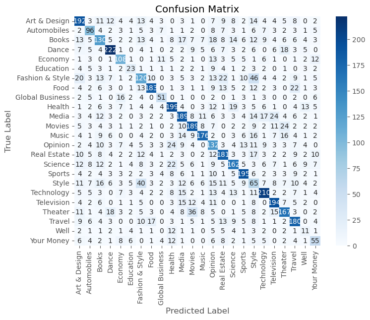

```python
# Evaluation with Testing Dataset:

# Get predictions for the testing data
predictions_prob = model.predict(padded_test_sequences)
predictions = np.argmax(predictions_prob, axis=1)

# Calculate precision, recall, and F1 score
accuracy = accuracy_score(encoded_test_labels, predictions)
print("Accuracy on testing data:", accuracy)
report = classification_report(encoded_test_labels, predictions, target_names=label_encoder.classes_)
print("Classification Report:")
print(report)

# Plot confusion matrix
conf_matrix = confusion_matrix(encoded_test_labels, predictions)
plt.figure(figsize=(8, 6))
sns.heatmap(conf_matrix, annot=True, fmt="d", cmap="Blues", xticklabels=label_encoder.classes_, yticklabels=label_encoder.classes_)
plt.title("Confusion Matrix")
plt.xlabel("Predicted Label")
plt.ylabel("True Label")
plt.show()
```

For modeling, I initially chose Naive Bayes because it's suitable for text classification tasks where features are assumed to be independent. However, Naive Bayes may oversimplify relationships between words. Hence, I also explored BiLSTM, a deep learning model capable of capturing complex sequential patterns in text data.

## Categorize news articles into their respective categories

## To evaluate the performance of both the BiLSTM and Naive Bayes models,enter any text into the sentences area and see where each model places it.

## Naive Bayes

```python
# Given list of sentences
sentences = [
    "New study reveals insights into human behavior",
    "Stock market experiences a sharp decline",
    "Latest technology trends shaping the future",
    "Political leaders discuss climate change policies",
    "Health experts warn about the dangers of obesity"
]

# Tokenize and transform the sequences
X_sentences = vectorizer.transform(sentences)

# Predict category labels
predicted_labels = model_nb.predict(X_sentences)

# Convert numeric labels back to text labels
predicted_categories = label_encoder.inverse_transform(predicted_labels)

# Print predicted category labels for each sentence
for sentence, category in zip(sentences, predicted_categories):
    print(f"Sentence: {sentence} - Predicted section: {category}")
```

```
Sentence: New study reveals insights into human behavior - Predicted section: Science
Sentence: Stock market experiences a sharp decline - Predicted section: Your Money
Sentence: Latest technology trends shaping the future - Predicted section: Technology
Sentence: Political leaders discuss climate change policies - Predicted section: Science
Sentence: Health experts warn about the dangers of obesity - Predicted section: Health
```

## BiLSTM

```python
# Given list of sentences
sentences = [
    "New study reveals insights into human behavior",
    "Stock market experiences a sharp decline",
    "Latest technology trends shaping the future",
    "Political leaders discuss climate change policies",
    "Health experts warn about the dangers of obesity"
]

# Tokenize and pad the sequences
sentence_sequences = tokenizer.texts_to_sequences(sentences)
padded_sentence_sequences = pad_sequences(sentence_sequences, maxlen=maxlen, padding='post')

# Predict category labels
predicted_labels = model.predict(padded_sentence_sequences)
predicted_categories = label_encoder.inverse_transform(np.argmax(predicted_labels, axis=1))

# Print predicted category labels for each sentence
for sentence, category in zip(sentences, predicted_categories):
    print(f"Sentence: {sentence} - Predicted section: {category}")
```

```
1/1 ━━━━━━━━━━━━━━━━━━━━ 0s 11ms/step
Sentence: New study reveals insights into human behavior - Predicted section: Books
Sentence: Stock market experiences a sharp decline - Predicted section: Your Money
Sentence: Latest technology trends shaping the future - Predicted section: Technology
Sentence: Political leaders discuss climate change policies - Predicted section: Opinion
Sentence: Health experts warn about the dangers of obesity - Predicted section: Health
```